# Question

A length of red string is pulled around the circle with radius $r=7$. The red string [subtends](https://en.wikipedia.org/wiki/Subtended_angle) a [central angle](https://en.wikipedia.org/wiki/Central_angle) with a degree measure of $\psi$°, and the red string also subtends an **[inscribed angle](https://en.wikipedia.org/wiki/Inscribed_angle)** with degree measure of 62°.

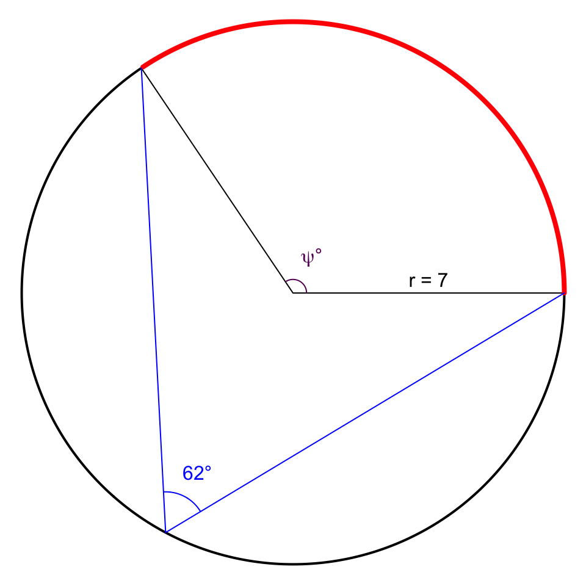

How long, in centimeters, is the red string? Please answer as a decimal approximation accurate within $\pm 0.01$ centimeters.

# Solution

The **[inscribed angle theorem](https://en.wikipedia.org/wiki/Inscribed_angle#Statement)** states that an angle $\theta$ inscribed in a circle is half of the central angle $2\theta$ that intercepts the same arc on the circle. Surprisingly, this is independent of where the inscribed angle sits on the circle. I find [this animation](https://en.wikipedia.org/wiki/Inscribed_angle#/media/File:ArcCapable.gif) helpful. Please take a moment to internalize this theorem, as it shows up frequently on standardized tests.

Anyway, for this problem, from the inscribed-angle theorem, we know $\psi=2\cdot 62=124$. In other words, our central angle is twice the corresponding inscribed angle.

Find the [diameter](https://en.wikipedia.org/wiki/Diameter).

$$d=2r$$
$$d=2\cdot7$$
$$d=14$$

Find the [circumference](https://en.wikipedia.org/wiki/Circumference).

$$C = \pi d$$
$$C = \pi \cdot 14$$
$$C~\approx~43.9822972$$

Remember, there are $360^{\circ}$ in a full circle. The [string’s length](https://en.wikipedia.org/wiki/Circular_arc) is $\frac{124}{360}$ of the circumference.

$$L~=~\frac{124}{360}C$$
$$L~=~\frac{124}{360}d\pi$$
$$L~=~\frac{124}{360}2\pi r$$
$$L~\approx~\frac{124}{360}(43.9822972)$$
$$L~\approx~15.1494579$$

# Meta-information

extype: num exsolution: 15.1494579 exname: arc_length_from_frac extol: 0.01